# Proyecto Final: Parte 3 - Rendimientos, Volatilidad y Simulación del Precio

Jeronimo Rojas Alvarado (731609), Alan Jesús Hernández Soto (752714), Francisco Josué Ramírez Avila (747819), JP Mendez

16 de octubre de 2026

# 1 1. Introducción

En las dos primeras entregas del proyecto se analizó a Banco del Bajío (BanBajío) desde dos perspectivas complementarias. Primero se estudió el modelo de negocio, la información financiera y los principales riesgos del banco. Después se analizó el comportamiento histórico de la acción **BBAJIOO**, identificando periodos de alzas, caídas, un máximo *drawdown* importante y la relación de esos movimientos con eventos económicos, políticos y empresariales.

En esta tercera parte el análisis se concentra en la distribución de los rendimientos, la volatilidad y la simulación del precio. El objetivo es evaluar hasta qué punto los datos observados son consistentes con los supuestos utilizados por el Movimiento Browniano Geométrico (GBM) y, posteriormente, utilizar los parámetros estimados para construir escenarios futuros de precio.

El documento se organiza en cinco etapas. Primero se calculan los rendimientos logarítmicos y medidas de volatilidad, tanto para toda la muestra reciente como año por año. Después se aplican pruebas de normalidad de Jarque-Bera y una prueba t para la media diaria. En seguida se estiman los parámetros del GBM en frecuencia diaria y anual y se realizan simulaciones para distintos horizontes. Finalmente, se contrastan los resultados empíricos con los supuestos teóricos del modelo y se discuten sus implicaciones para la medición del riesgo.

**Nota metodológica sobre las fechas.** La consigna utiliza dos cortes de información. Para las pruebas estadísticas y la estimación del GBM se solicita información **hasta el último día de 2025**; al mismo tiempo, en el apartado de estimaciones descriptivas se pide utilizar información **desde 2021 hasta lo que va de 2026**. Para cumplir ambas indicaciones, se usan dos subconjuntos: una muestra principal que termina el 31 de diciembre de 2025 y una muestra descriptiva 2021-2026. Las observaciones de 2026 no entran en las pruebas de normalidad, la prueba t ni la calibración del GBM.

# 2 2. Cálculo de rendimientos y volatilidad

## 2.1 2.1 Metodología

El rendimiento logarítmico diario se define como

$$r_t=\ln\left(\frac{S_t}{S_{t-1}}\right)=\ln(S_t)-\ln(S_{t-1}).$$

A partir de una muestra de $n$ rendimientos, el rendimiento promedio diario se estima como

$$\bar r=\frac{1}{n}\sum_{t=1}^{n}r_t,$$

y la volatilidad diaria mediante la desviación estándar muestral

$$s=\sqrt{\frac{1}{n-1}\sum_{t=1}^{n}(r_t-\bar r)^2}.$$

Siguiendo la metodología utilizada en clase, se emplean 252 días bursátiles por año. La media logarítmica anualizada y la volatilidad anualizada se calculan como

$$\bar r_{anual}=252\bar r,$$

$$\sigma_{anual}=\sigma_{diaria}\sqrt{252}.$$

La regla de la raíz del tiempo supone que la estructura de varianza es suficientemente estable y que las covarianzas entre rendimientos de distintos días no alteran de forma importante la agregación. Por ello, la anualización es una aproximación útil, pero no implica que la volatilidad sea realmente constante a lo largo del tiempo.

## 2.2 2.2 Descarga de datos

Para mantener consistencia con la segunda entrega del proyecto y con la indicación de utilizar el último **precio de cotización**, el análisis principal se realiza con el **precio de cierre** de Yahoo Finance. La implementación conserva la estructura utilizada en clase con `quantmod`, pero se aplica `Cl()` porque en esta entrega el objeto que se modela es el precio de mercado observado. La misma serie de cierre se utiliza para calcular los rendimientos y para definir el valor inicial del GBM, evitando mezclar escalas distintas.

```r
library(quantmod)
library(xts)
library(moments)
library(tseries)
```

```r
clave <- "BBAJIOO.MX"

# Muestra principal: desde la salida a bolsa hasta el cierre de 2025.
# En Yahoo/quantmod el argumento 'to' funciona como límite superior,
# por eso se usa 2026-01-01 para incluir el 31/12/2025.
datos <- getSymbols(
  clave,
  src = "yahoo",
  from = "2017-06-01",
  to = "2026-01-01",
  auto.assign = FALSE
)

precio <- na.omit(Cl(datos))
names(precio) <- "precio"

# Muestra adicional para cumplir la estimación 2021 - 2026 YTD.
# El corte se fija a la fecha de elaboración para mantener reproducibilidad.
datos_2026 <- getSymbols(
  clave,
  src = "yahoo",
  from = "2021-01-01",
  to = "2026-10-17",
  auto.assign = FALSE
)

precio_21_26 <- na.omit(Cl(datos_2026))
names(precio_21_26) <- "precio"
```

```r
periodo_principal <- data.frame(
  Inicio = as.character(first(index(precio))),
  Fin = as.character(last(index(precio))),
  Observaciones = NROW(precio)
)

periodo_reciente <- data.frame(
  Inicio = as.character(first(index(precio_21_26))),
  Fin = as.character(last(index(precio_21_26))),
  Observaciones = NROW(precio_21_26)
)

knitr::kable(periodo_principal, caption = "Muestra principal utilizada hasta 2025")
```

Muestra principal utilizada hasta 2025

| Inicio | Fin | Observaciones |
| --- | --- | --- |
| 2017-06-08 | 2025-12-31 | 2155 |

```r
knitr::kable(periodo_reciente, caption = "Muestra descriptiva 2021-2026")
```

Muestra descriptiva 2021-2026

| Inicio | Fin | Observaciones |
| --- | --- | --- |
| 2021-01-04 | 2026-10-16 | 1457 |

## 2.3 2.3 Rendimiento logarítmico diario

```r
rendimientos <- dailyReturn(precio, type="log")
names(rendimientos) <- "rendimiento"

rendimientos_21_26 <- dailyReturn(precio_21_26, type="log")
names(rendimientos_21_26) <- "rendimiento"

head(rendimientos)
```

```
##              rendimiento
## 2017-06-08  0.0000000000
## 2017-06-09  0.0039735430
## 2017-06-12  0.0078999677
## 2017-06-13 -0.0032840877
## 2017-06-14  0.0029561576
## 2017-06-15 -0.0003280377
```

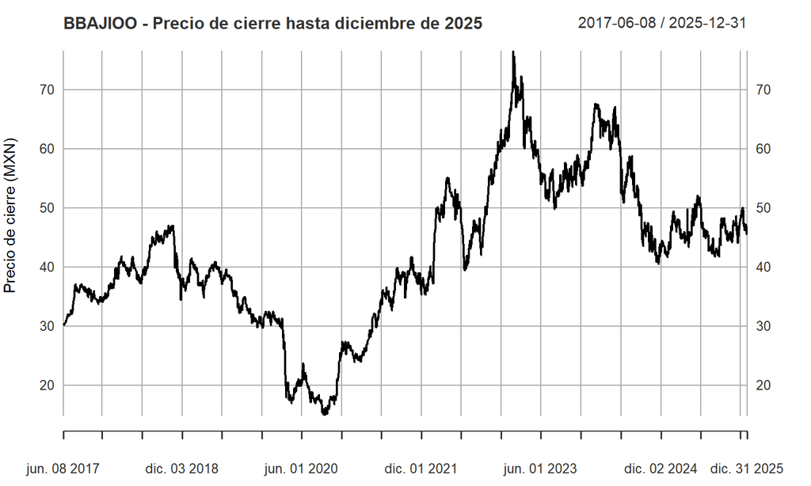

```r
plot(
  precio,
  main = "BBAJIOO - Precio de cierre hasta diciembre de 2025",
  xlab = "Fecha",
  ylab = "Precio de cierre (MXN)"
)
```

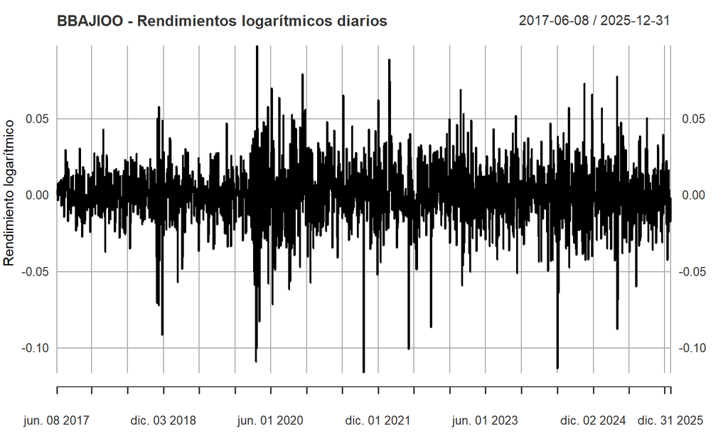

```r
plot(
  rendimientos,
  main = "BBAJIOO - Rendimientos logarítmicos diarios",
  xlab = "Fecha",
  ylab = "Rendimiento logarítmico"
)
abline(h = 0, lty = 2)
```

## 2.4 2.4 Estimaciones 2021-2026 YTD

```r
dias_cot <- 252

r_21_26 <- as.numeric(na.omit(rendimientos_21_26))
mean_log_21_26 <- mean(r_21_26)
sigma_log_21_26 <- sd(r_21_26)
mean_log_anual_21_26 <- dias_cot*mean_log_21_26
sigma_anual_21_26 <- sigma_log_21_26*sqrt(dias_cot)

tabla_total <- data.frame(
  Indicador = c(
    "Rendimiento promedio diario",
    "Volatilidad diaria",
    "Rendimiento promedio anualizado",
    "Volatilidad anualizada"
  ),
  Valor = c(
    mean_log_21_26,
    sigma_log_21_26,
    mean_log_anual_21_26,
    sigma_anual_21_26
  ),
  Porcentaje = 100*c(
    mean_log_21_26,
    sigma_log_21_26,
    mean_log_anual_21_26,
    sigma_anual_21_26
  )
)

knitr::kable(tabla_total, digits=6, caption="Estimaciones con información 2021-2026 YTD")
```

Estimaciones con información 2021-2026 YTD

| Indicador | Valor | Porcentaje |
| --- | --- | --- |
| Rendimiento promedio diario | 0.000539 | 0.053925 |
| Volatilidad diaria | 0.019766 | 1.976603 |
| Rendimiento promedio anualizado | 0.135892 | 13.589208 |
| Volatilidad anualizada | 0.313776 | 31.377593 |

La media diaria debe interpretarse en conjunto con la volatilidad. En series financieras el rendimiento medio diario suele ser pequeño en relación con la dispersión diaria. Por esta razón, el riesgo de corto plazo está dominado por la variabilidad alrededor de la media y no únicamente por el signo del rendimiento esperado.

## 2.5 2.5 Estimaciones año por año

```r
anios <- 2021:2026
tabla_anual <- data.frame()

for (anio in anios) {
  r_anio <- na.omit(rendimientos_21_26[paste0(anio)])
  r_num <- as.numeric(r_anio)

  tabla_anual <- rbind(
    tabla_anual,
    data.frame(
      Anio = ifelse(anio==2026, "2026 YTD", as.character(anio)),
      Observaciones = length(r_num),
      Rendimiento_promedio_diario = mean(r_num),
      Volatilidad_diaria = sd(r_num),
      Rendimiento_anualizado = dias_cot*mean(r_num),
      Volatilidad_anualizada = sd(r_num)*sqrt(dias_cot)
    )
  )
}

knitr::kable(
  tabla_anual,
  digits = 6,
  caption = "Rendimiento y volatilidad de BBAJIOO por año"
)
```

Rendimiento y volatilidad de BBAJIOO por año

| Anio | Observaciones | Rendimiento_promedio_diario | Volatilidad_diaria | Rendimiento_anualizado | Volatilidad_anualizada |
| --- | --- | --- | --- | --- | --- |
| 2021 | 253 | 0.001320 | 0.019118 | 0.332709 | 0.303485 |
| 2022 | 252 | 0.002030 | 0.019959 | 0.511586 | 0.316841 |
| 2023 | 251 | -0.000316 | 0.019630 | -0.079626 | 0.311616 |
| 2024 | 251 | -0.001229 | 0.021876 | -0.309702 | 0.347264 |
| 2025 | 251 | 0.000357 | 0.019609 | 0.090086 | 0.311278 |
| 2026 YTD | 199 | 0.001197 | 0.017822 | 0.301554 | 0.282913 |

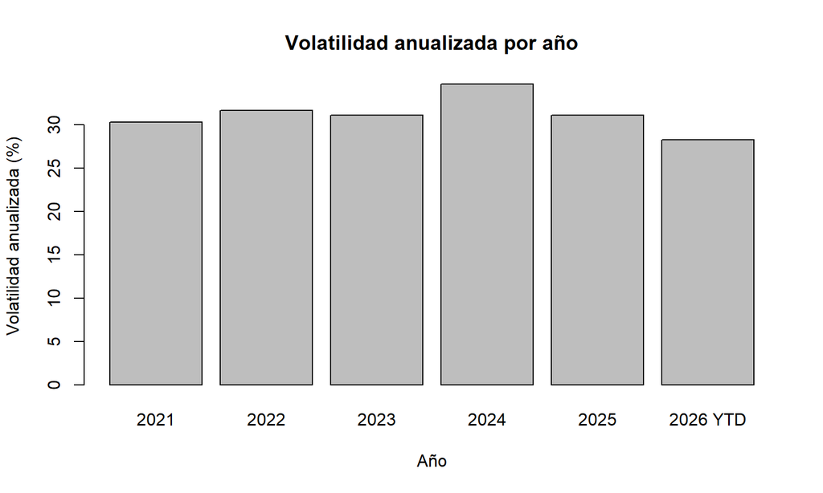

```r
barplot(
  100*tabla_anual$Volatilidad_anualizada,
  names.arg = tabla_anual$Anio,
  main = "Volatilidad anualizada por año",
  xlab = "Año",
  ylab = "Volatilidad anualizada (%)"
)
```

El año con la mayor volatilidad anualizada de la muestra reciente es **2024**, con aproximadamente **34.73%**. El menor nivel corresponde a **2026 YTD**, con aproximadamente **28.29%**. Por su parte, el mayor rendimiento medio anualizado aparece en **2022**, mientras que el menor se observa en **2024**. La diferencia entre años muestra que tanto el centro como la dispersión de los rendimientos cambian a través del tiempo. Esto es consistente con la evidencia observada en la Parte 2 del proyecto, donde BBAJIOO presentó periodos de recuperación, correcciones y choques de distinta intensidad. Sin embargo, una diferencia entre volatilidades anuales no constituye por sí sola una prueba formal de cambio estructural; sí es evidencia descriptiva de que el supuesto de una sola volatilidad constante es restrictivo. Esta observación conecta con la unidad de volatilidad dinámica, donde la varianza se modela como una cantidad que puede cambiar con el tiempo. El dato de 2026 se presenta como YTD: su media diaria se anualiza para hacerla comparable, pero no representa un rendimiento realizado de un año completo.

# 3 3. Pruebas estadísticas

## 3.1 3.1 Metodología de Jarque-Bera

La prueba de Jarque-Bera contrasta si una muestra presenta asimetría y curtosis compatibles con una distribución normal. Las hipótesis son

$$H_0:\text{ la serie es compatible con normalidad},$$

$$H_a:\text{ la serie no es compatible con normalidad}.$$

El estadístico es

$$JB=\frac{n}{6}\left[S^2+\frac{(K-3)^2}{4}\right],$$

donde $S$ representa la asimetría y $K$ la curtosis. Bajo normalidad se espera $S=0$ y $K=3$. Con un nivel de significancia de 5%, se rechaza $H_0$ si el valor-p es menor que 0.05.

```r
r <- as.numeric(na.omit(rendimientos))
p <- as.numeric(na.omit(precio))
ln_p <- log(p)
```

```r
jb_rend <- jarque.bera.test(r)
jb_precio <- jarque.bera.test(p)
jb_logprecio <- jarque.bera.test(ln_p)

jb_rend
```

```
##
##  Jarque Bera Test
##
## data:  r
## X-squared = 1294.9, df = 2, p-value < 0.00000000000000022
```

```r
jb_precio
```

```
##
##  Jarque Bera Test
##
## data:  p
## X-squared = 8.1308, df = 2, p-value = 0.01716
```

```r
jb_logprecio
```

```
##
##  Jarque Bera Test
##
## data:  ln_p
## X-squared = 279.96, df = 2, p-value < 0.00000000000000022
```

```r
forma_series <- data.frame(
  Serie = c("Rendimientos", "Precio", "Log precio"),
  Asimetria = c(skewness(r), skewness(p), skewness(ln_p)),
  Curtosis = c(kurtosis(r), kurtosis(p), kurtosis(ln_p)),
  JB = c(
    as.numeric(jb_rend$statistic),
    as.numeric(jb_precio$statistic),
    as.numeric(jb_logprecio$statistic)
  ),
  P_value = c(jb_rend$p.value, jb_precio$p.value, jb_logprecio$p.value)
)

knitr::kable(
  forma_series,
  digits = 6,
  caption = "Normalidad, asimetría y curtosis"
)
```

Normalidad, asimetría y curtosis

| Serie | Asimetria | Curtosis | JB | P_value |
| --- | --- | --- | --- | --- |
| Rendimientos | -0.359967 | 6.728715 | 1294.94162 | 0.000000 |
| Precio | 0.047121 | 2.714220 | 8.13078 | 0.017156 |
| Log precio | -0.829457 | 3.604839 | 279.95503 | 0.000000 |

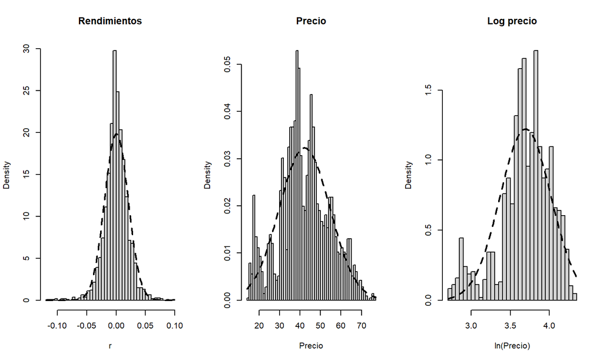

```r
par(mfrow=c(1,3))

hist(r, breaks=50, probability=TRUE,
     main="Rendimientos", xlab="r")
curve(dnorm(x, mean=mean(r), sd=sd(r)), add=TRUE, lty=2, lwd=2)

hist(p, breaks=50, probability=TRUE,
     main="Precio", xlab="Precio")
curve(dnorm(x, mean=mean(p), sd=sd(p)), add=TRUE, lty=2, lwd=2)

hist(ln_p, breaks=50, probability=TRUE,
     main="Log precio", xlab="ln(Precio)")
curve(dnorm(x, mean=mean(ln_p), sd=sd(ln_p)), add=TRUE, lty=2, lwd=2)
```

```r
par(mfrow=c(1,1))
```

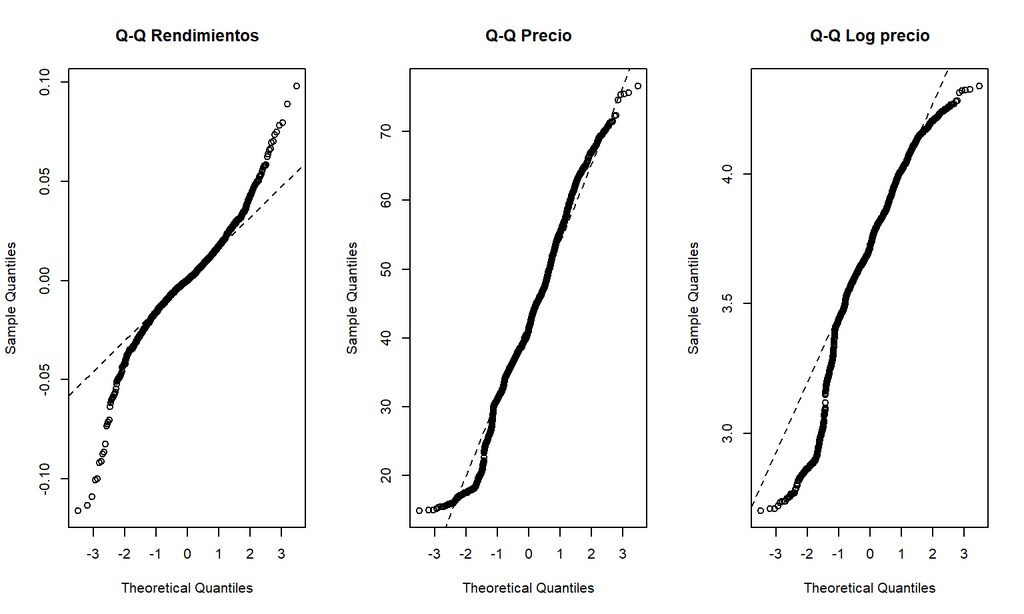

```r
par(mfrow=c(1,3))
qqnorm(r, main="Q-Q Rendimientos")
qqline(r, lty=2)
qqnorm(p, main="Q-Q Precio")
qqline(p, lty=2)
qqnorm(ln_p, main="Q-Q Log precio")
qqline(ln_p, lty=2)
```

```r
par(mfrow=c(1,1))
```

**Rendimientos.** Se rechaza la hipótesis de normalidad al 5%. Esto significa que el modelo normal no reproduce completamente la forma empírica de los rendimientos diarios. La asimetría y la curtosis permiten identificar si la desviación se relaciona con falta de simetría, colas pesadas o ambas. Financiera y estadísticamente, este resultado es relevante porque una normal puede asignar probabilidades demasiado pequeñas a movimientos extremos.

**Precio.** Se rechaza la normalidad del nivel de precios. Este resultado es coherente con que un proceso de precios positivo y con tendencia no tenga por qué distribuirse normalmente cuando se mezclan observaciones correspondientes a fechas distintas.

**Log precio.** También se rechaza la normalidad del logaritmo del precio considerado como una sola muestra temporal. Esto no contradice de manera automática la solución del GBM: el modelo establece que, condicionado a un precio inicial y para un horizonte fijo, $\ln S_T$ es normal. Una serie histórica reúne fechas con medias y varianzas distintas, por lo que esta prueba sobre niveles debe interpretarse de forma descriptiva y no como la única prueba del modelo.

## 3.2 3.2 Prueba t de media diaria igual a cero

Las hipótesis son

$$H_0:\mu_r=0,$$

$$H_a:\mu_r\neq0.$$

El estadístico t es

$$t=\frac{\bar r-0}{s/\sqrt{n}},$$

donde $\bar r$ es la media muestral, $s$ la desviación estándar y $n$ el número de observaciones.

```r
media_r <- mean(r)
sd_r <- sd(r)
n_r <- length(r)
t_manual <- media_r/(sd_r/sqrt(n_r))

prueba_t <- t.test(r, mu=0, alternative="two.sided")

t_manual
```

```
## [1] 0.4434622
```

```r
prueba_t
```

```
##
##  One Sample t-test
##
## data:  r
## t = 0.44346, df = 2154, p-value = 0.6575
## alternative hypothesis: true mean is not equal to 0
## 95 percent confidence interval:
##  -0.000656131  0.001039590
## sample estimates:
##    mean of x
## 0.0001917295
```

El valor-p de la prueba t es **0.65748**, por lo que no se rechaza $H_0$ al 5%. No hay evidencia suficiente para afirmar que el rendimiento promedio diario sea distinto de cero. Este resultado es consistente con la idea de que el rendimiento diario tiene una señal media pequeña frente a su volatilidad y con una predictibilidad limitada del rendimiento de muy corto plazo. No constituye, por sí solo, una prueba completa de eficiencia de mercado.

# 4 4. Estimación del modelo con parámetros diarios

## 4.1 4.1 Del rendimiento logarítmico al parámetro de drift del GBM

El Movimiento Browniano Geométrico se expresa como

$$dS_t=\mu S_t\,dt+\sigma S_t\,dW_t.$$

Al aplicar Itô a $\ln S_t$ se obtiene

$$d\ln S_t=\left(\mu-\frac{1}{2}\sigma^2\right)dt+\sigma dW_t.$$

Por tanto, para un intervalo de un día,

$$E[r_t]=\mu-\frac{1}{2}\sigma^2.$$

La media de los log-rendimientos no es directamente el parámetro $\mu$ de la ecuación del precio. Siguiendo el procedimiento utilizado en clase,

$$\hat\mu_{diario}=\bar r+\frac{1}{2}\hat\sigma_{diaria}^2.$$

La solución exacta utilizada para simular es

$$S_T=S_0\exp\left[\left(\mu-\frac{1}{2}\sigma^2\right)T+\sigma\sqrt{T}Z\right],
\qquad Z\sim N(0,1).$$

El precio esperado teórico es

$$E[S_T]=S_0e^{\mu T}.$$

El intervalo al 95% bajo el modelo se obtiene con los cuantiles 2.5% y 97.5% de la distribución lognormal:

$$S_{inf}=S_0\exp\left[\left(\mu-\frac12\sigma^2\right)T+z_{0.025}\sigma\sqrt
T\right],$$

$$S_{sup}=S_0\exp\left[\left(\mu-\frac12\sigma^2\right)T+z_{0.975}\sigma\sqrt
T\right].$$

Este intervalo se interpreta como un **intervalo predictivo/modelado del 95% para el precio** bajo los supuestos del GBM. No incorpora incertidumbre adicional por error en la estimación de $\mu$ y $\sigma$.

```r
mean_log <- mean(rendimientos, na.rm=TRUE)
sigma_log <- sd(rendimientos, na.rm=TRUE)
mu_gbm_diario <- mean_log + 0.5*sigma_log^2

So <- as.numeric(last(precio))
mu <- mu_gbm_diario
sigma <- sigma_log

parametros_diarios <- data.frame(
  Parametro = c("S0", "Media log diaria", "Sigma diaria", "Mu GBM diario"),
  Valor = c(So, mean_log, sigma_log, mu_gbm_diario)
)

knitr::kable(parametros_diarios, digits=8, caption="Parámetros diarios del GBM")
```

Parámetros diarios del GBM

| Parametro | Valor |
| --- | --- |
| S0 | 45.56000137 |
| Media log diaria | 0.00019173 |
| Sigma diaria | 0.02007039 |
| Mu GBM diario | 0.00039314 |

Con los parámetros estimados, la ecuación diaria queda numéricamente como:

$$dS_t = 0.00039314\,S_t\,dt +
0.02007039\,S_t\,dW_t.$$

```r
gbm_summary <- function(So, mu, sigma, T, nc){
  z_nc <- qnorm(1-(1-nc)/2)
  c(
    Precio_Esperado=So*exp(mu*T),
    Mediana=So*exp((mu-.5*sigma^2)*T),
    inferior=So*exp((mu-.5*sigma^2)*T-z_nc*sigma*sqrt(T)),
    superior=So*exp((mu-.5*sigma^2)*T+z_nc*sigma*sqrt(T))
  )
}
```

## 4.2 4.2 Simulación a 10, 20 y 40 días

Se generan 100,000 shocks normales estándar y se utiliza la solución exacta del GBM. Con parámetros diarios, el tiempo se mide en días bursátiles: $T=10$, $20$ y $40$.

```r
set.seed(456)
z <- rnorm(100000, mean=0, sd=1)

St_10d <- So*exp((mu-.5*sigma^2)*10+sigma*sqrt(10)*z)
St_20d <- So*exp((mu-.5*sigma^2)*20+sigma*sqrt(20)*z)
St_40d <- So*exp((mu-.5*sigma^2)*40+sigma*sqrt(40)*z)
```

```r
res_10d <- gbm_summary(So, mu, sigma, 10, .95)
res_20d <- gbm_summary(So, mu, sigma, 20, .95)
res_40d <- gbm_summary(So, mu, sigma, 40, .95)

tabla_diaria <- data.frame(
  Horizonte = c("10 días", "20 días", "40 días"),
  Media_simulada = c(mean(St_10d), mean(St_20d), mean(St_40d)),
  Precio_esperado_teorico = c(res_10d["Precio_Esperado"], res_20d["Precio_Esperado"], res_40d["Precio_Esperado"]),
  Limite_inferior_95 = c(res_10d["inferior"], res_20d["inferior"], res_40d["inferior"]),
  Limite_superior_95 = c(res_10d["superior"], res_20d["superior"], res_40d["superior"])
)

tabla_diaria$Amplitud_intervalo <- tabla_diaria$Limite_superior_95-tabla_diaria$Limite_inferior_95

knitr::kable(tabla_diaria, digits=4, caption="Simulación del precio con parámetros diarios")
```

Simulación del precio con parámetros diarios

| Horizonte | Media_simulada | Precio_esperado_teorico | Limite_inferior_95 | Limite_superior_95 | Amplitud_intervalo |
| --- | --- | --- | --- | --- | --- |
| 10 días | 45.7572 | 45.7395 | 40.3081 | 51.6941 | 11.3860 |
| 20 días | 45.9456 | 45.9196 | 38.3572 | 54.5319 | 16.1747 |
| 40 días | 46.3208 | 46.2821 | 35.7986 | 58.8793 | 23.0807 |

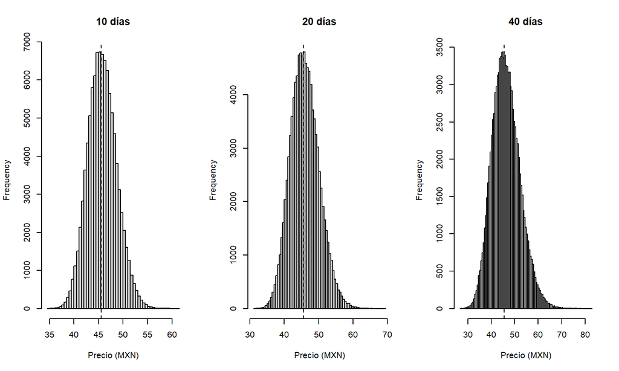

```r
par(mfrow=c(1,3))
hist(St_10d, breaks=80, main="10 días", xlab="Precio (MXN)")
abline(v=So, lty=2)
hist(St_20d, breaks=80, main="20 días", xlab="Precio (MXN)")
abline(v=So, lty=2)
hist(St_40d, breaks=80, main="40 días", xlab="Precio (MXN)")
abline(v=So, lty=2)
```

```r
par(mfrow=c(1,1))
```

La amplitud del intervalo modelado al 95% pasa de aproximadamente **$11.39** a 10 días a **$23.08** a 40 días. El aumento ocurre porque el término aleatorio del GBM escala con $\sqrt{T}$. La media esperada también cambia con el horizonte por el componente de drift, pero para la medición de riesgo la ampliación de la distribución es central: cuanto más tiempo transcurre, mayor es el conjunto de precios compatibles con el modelo. Esto significa que una proyección puntual pierde información importante si no se presenta junto con su intervalo de incertidumbre.

# 5 5. Estimación del modelo con parámetros anuales

## 5.1 5.1 Anualización de parámetros

A partir de los rendimientos diarios hasta 2025,

$$\sigma_{anual}=\sigma_{diaria}\sqrt{252},$$

$$\bar r_{log,anual}=252\bar r_{diario},$$

y el parámetro anual del GBM es

$$\mu_{GBM,anual}=252\bar r_{diario}+\frac12\sigma_{anual}^2.$$

```r
sigma_anual <- sigma_log*sqrt(dias_cot)
mu_log_anual <- dias_cot*mean_log
mu_gbm_anual <- mu_log_anual+0.5*sigma_anual^2

parametros_anuales <- data.frame(
  Parametro = c("Media log anualizada", "Sigma anual", "Mu GBM anual"),
  Valor = c(mu_log_anual, sigma_anual, mu_gbm_anual)
)

knitr::kable(parametros_anuales, digits=6, caption="Parámetros anualizados del GBM")
```

Parámetros anualizados del GBM

| Parametro | Valor |
| --- | --- |
| Media log anualizada | 0.048316 |
| Sigma anual | 0.318608 |
| Mu GBM anual | 0.099071 |

En escala anual, la ecuación estimada del GBM es:

$$dS_t = 0.099071\,S_t\,dt +
0.318608\,S_t\,dW_t.$$

## 5.2 5.2 Simulación a 3, 6, 9 y 12 meses

Ahora el tiempo se mide en años:

$$T\in\{0.25,0.50,0.75,1.00\}.$$

```r
mu <- mu_gbm_anual
sigma <- sigma_anual

set.seed(456)
z_anual <- rnorm(100000, mean=0, sd=1)

St_3m <- So*exp((mu-.5*sigma^2)*.25+sigma*sqrt(.25)*z_anual)
St_6m <- So*exp((mu-.5*sigma^2)*.50+sigma*sqrt(.50)*z_anual)
St_9m <- So*exp((mu-.5*sigma^2)*.75+sigma*sqrt(.75)*z_anual)
St_12m <- So*exp((mu-.5*sigma^2)*1+sigma*sqrt(1)*z_anual)
```

```r
res_3m <- gbm_summary(So, mu, sigma, .25, .95)
res_6m <- gbm_summary(So, mu, sigma, .50, .95)
res_9m <- gbm_summary(So, mu, sigma, .75, .95)
res_12m <- gbm_summary(So, mu, sigma, 1, .95)

tabla_anual_gbm <- data.frame(
  Horizonte = c("3 meses", "6 meses", "9 meses", "12 meses"),
  Media_simulada = c(mean(St_3m), mean(St_6m), mean(St_9m), mean(St_12m)),
  Precio_esperado_teorico = c(
    res_3m["Precio_Esperado"],
    res_6m["Precio_Esperado"],
    res_9m["Precio_Esperado"],
    res_12m["Precio_Esperado"]
  ),
  Limite_inferior_95 = c(res_3m["inferior"], res_6m["inferior"], res_9m["inferior"], res_12m["inferior"]),
  Limite_superior_95 = c(res_3m["superior"], res_6m["superior"], res_9m["superior"], res_12m["superior"])
)

tabla_anual_gbm$Amplitud_intervalo <- tabla_anual_gbm$Limite_superior_95-tabla_anual_gbm$Limite_inferior_95

knitr::kable(tabla_anual_gbm, digits=4, caption="Simulación del precio con parámetros anualizados")
```

Simulación del precio con parámetros anualizados

| Horizonte | Media_simulada | Precio_esperado_teorico | Limite_inferior_95 | Limite_superior_95 | Amplitud_intervalo |
| --- | --- | --- | --- | --- | --- |
| 3 meses | 46.7534 | 46.7025 | 33.7466 | 63.0129 | 29.2663 |
| 6 meses | 47.9531 | 47.8737 | 30.0129 | 72.5842 | 42.5713 |
| 9 meses | 49.1795 | 49.0742 | 27.5078 | 81.1310 | 53.6232 |
| 12 meses | 50.4351 | 50.3048 | 25.6075 | 89.2825 | 63.6750 |

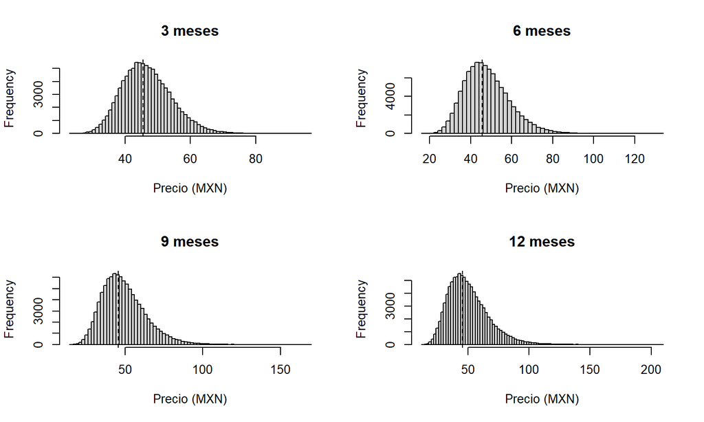

```r
par(mfrow=c(2,2))
hist(St_3m, breaks=80, main="3 meses", xlab="Precio (MXN)")
abline(v=So, lty=2)
hist(St_6m, breaks=80, main="6 meses", xlab="Precio (MXN)")
abline(v=So, lty=2)
hist(St_9m, breaks=80, main="9 meses", xlab="Precio (MXN)")
abline(v=So, lty=2)
hist(St_12m, breaks=80, main="12 meses", xlab="Precio (MXN)")
abline(v=So, lty=2)
```

```r
par(mfrow=c(1,1))
```

En la escala anual, la amplitud del intervalo modelado aumenta de aproximadamente **$29.27** a tres meses a **$63.67** a doce meses. La dispersión crece con el horizonte porque el componente de difusión se acumula con la raíz del tiempo y, además, la transformación exponencial hace que la distribución del precio sea asimétrica. Por ello, el riesgo de horizonte largo no debe resumirse únicamente mediante el precio esperado: la distancia entre escenarios bajos y altos se vuelve considerablemente mayor.